# Practical Machine Learning Peer Assignment 01

Friday, June 20, 2014

# Executive Summary

To predict the **classe** classification given **pml-training.csv**, three supervised machine learning models were trained, and 95% accuracy estimate bands were calculated for each model using a re-sampling technique (caret default).

| Model | Out of Sample Accuracy | 95% Accuracy Estimate Band |
| --- | --- | --- |
| *Random Forest*(rf) | **98.5%** | [96.32%, 98.18%] |
| Stochastic Gradient Boosting (gbm) | 95.3% | [93.07%, 95.64%] |
| Support Vector Machines (svmRadial) | 88.6% | [82.44%, 88.17%] |

*NOTE: It is unusual that the Out of Sample Accuracy is at the upper end of each estimate band.*

70% of the training data was saved as Cross Validation data and used to calculate **out of sample error** estimates that were compared to the 95% accuracy estimate bands to provide confidence in the design methodology.

The **caret** model classes were used to optimize each model and to determine feature properties such as which predictive features were most important and to optimize model parameters.

A box plot of the of the Accuracy Error Bands was constructed to determine the best model, the **caret** **Random Forest(rf)** was a clear winner with a Cross Validation Out of Sample Accuracy of **98.5%**

Probabilities for each **classe** classification was used to predict not just the most likely, but also the second most likely answer.

# Model Design and Code Details

## Loading and cleaning data

The training and test data was loaded and all columns full of NA were removed. Likewise other non-predictive columns where removed to create clean tidy data.frame.

```r
dfRawTrain <- read.csv("pml-training.csv", sep=",") # dim=19622,160
dfRawTest <- read.csv("pml-testing.csv", sep=",") # dim=20,160

removeNames <- c("X", "user_name", "raw_timestamp_part_1", "raw_timestamp_part_2", "cvtd_timestamp", "new_window", "num_window","problem_id")
namesFeatures <- names(dfRawTest[,colSums(is.na(dfRawTest)) != nrow(dfRawTest)]) # Remove columns with NA
namesFeatures <- namesFeatures[ -which(namesFeatures %in% removeNames)] # Remove non-feature

dfTidyTrain <- dfRawTrain[, c("classe", namesFeatures)] # dim=19622,53
dfTidyTest <- dfRawTest[, c("problem_id", namesFeatures)] # dim=20,53
```

Due to the large amount of Training data and limited machine Memory capacity the Training data was split 30% training and 70% Cross Validation (much more than usual).

```r
set.seed(42)
idxSample <- createDataPartition(y=dfTidyTrain$classe, p=0.30, list=FALSE)
dfTrain <- dfTidyTrain[idxSample,] # dim=5889,53
dfCross <- dfTidyTrain[-idxSample,] # dim=13733,53
dfTest <- dfTidyTest # dim=20,53
```

## Exploratory analysis

Analysis was done on the Tidy Data, to detect outliers that might effect certain models. Nothing exceptional was found.

Each feature was numeric and QQ plots show each predictive feature to be reasonably behaved, leading one to think most machine learning algorithms will be appropriate with low variance. Many features were approximately normal with slightly shorter tails.

Example: **accel_forearm_x**

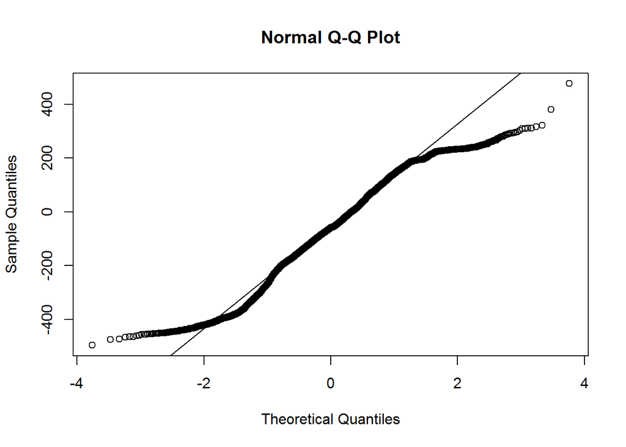

```r
qqnorm(dfTrain$accel_forearm_x)
qqline(dfTrain$accel_forearm_x)
```

## Model Selection

### Fitting models

NOTE: It should be noted that the **caret** models can utilize all CPU cores on a machine if **registerDoParallel()** is set.

```
c7 <- makeCluster(7)  # Use 7 CPU Cores
registerDoParallel(c7)
getDoParWorkers() # Verify how many cores will be used.

set.seed(42)
rfModel <- train(classe ~ ., data=dfTrain, method="rf", prox=TRUE)
rfModel
accuracyRange <- rfModel$results$Accuracy[2] + c(-1, 1) * 2 * rfModel$results$AccuracySD[2]
cat("95% Estimated Accuracy band = [", sprintf("%4.2f%%", accuracyRange*100), "]")
Accuracy(rfModel, "CV", dfCross) # 98.5%

set.seed(42)
gbmModel <- train(classe ~ ., data=dfTrain, method="gbm", verbose=FALSE)
gbmModel
accuracyRange <- gbmModel$results$Accuracy[9] + c(-1, 1) * 2 * gbmModel$results$AccuracySD[9]
cat("95% Estimated Accuracy band = [", sprintf("%4.2f%%", accuracyRange*100), "]")
Accuracy(gbmModel, "CV", dfCross) # 95.3%

set.seed(42)
svmModel <- train(classe ~ ., data=dfTrain, method="svmRadial", preProc = c("center", "scale"), metric = "Accuracy")
svmModel
accuracyRange <- svmModel$results$Accuracy[2] + c(-1, 1) * 2 * svmModel$results$AccuracySD[2]
cat("95% Estimated Accuracy band = [", sprintf("%4.2f%%", accuracyRange*100), "]")
Accuracy(svmModel, "CV", dfCross) # 88.6%

stopCluster(c7)
```

The **caret** models calculate **In Sample Accuracy Estimate** bands by default (using re-sampling). Accuracy bands are given for each model parameter values and the parameter values with best accuracy is automatically selected for the final model.

The Cross Validation data is then used to calculate an **Out of Sample Accuracy** that was compare to the **In Sample Accuracy Estimate** bands, as a sanity check.

[output not shown]

```
## 95% Estimated Accuracy band = [ 96.32% 98.18% ]
```

```
## [1] "randomForest CV Accuracy = 98.5%"
```

[output not shown]

```
## 95% Estimated Accuracy band = [ 93.07% 95.64% ]
```

```
## [1] "gbm CV Accuracy = 95.3%"
```

```
## Support Vector Machines with Radial Basis Function Kernel
##
## 5889 samples
##   52 predictors
##    5 classes: 'A', 'B', 'C', 'D', 'E'
##
## Pre-processing: centered, scaled
## Resampling: Bootstrapped (25 reps)
##
## Summary of sample sizes: 5889, 5889, 5889, 5889, 5889, 5889, ...
##
## Resampling results across tuning parameters:
##
##   C    Accuracy  Kappa  Accuracy SD  Kappa SD
##   0.2  0.8       0.7    0.02         0.02
##   0.5  0.9       0.8    0.01         0.02
##   1    0.9       0.9    0.01         0.01
##
## Tuning parameter 'sigma' was held constant at a value of 0.01418
## Accuracy was used to select the optimal model using  the largest value.
## The final values used for the model were sigma = 0.01 and C = 1.
```

```
## 95% Estimated Accuracy band = [ 82.44% 88.17% ]
```

```
## [1] "ksvm CV Accuracy = 88.6%"
```

The **rf** class optimization used only 27 of the 52 predictive features per tree. This is the optimal balance between bias error and variance error.

The most important predictive features were:

```r
varImp(rfModel)
```

```
## rf variable importance
##
##   only 20 most important variables shown (out of 52)
##
##                      Overall
## roll_belt              100.0
## pitch_forearm           62.9
## yaw_belt                55.2
## magnet_dumbbell_z       45.2
## pitch_belt              44.5
## magnet_dumbbell_y       43.1
## roll_forearm            37.2
## accel_dumbbell_y        25.2
## roll_dumbbell           23.0
## magnet_dumbbell_x       20.9
## accel_forearm_x         17.2
## accel_dumbbell_z        16.7
## magnet_belt_z           15.9
## magnet_belt_y           15.0
## accel_belt_z            14.5
## magnet_forearm_z        13.8
## total_accel_dumbbell    12.1
## gyros_belt_z            11.9
## yaw_arm                 10.7
## yaw_dumbbell            10.5
```

A box plot of the three models shows the **rf** Random Forest is a clear winner, based on the Accuracy and Kappa estimate bands.

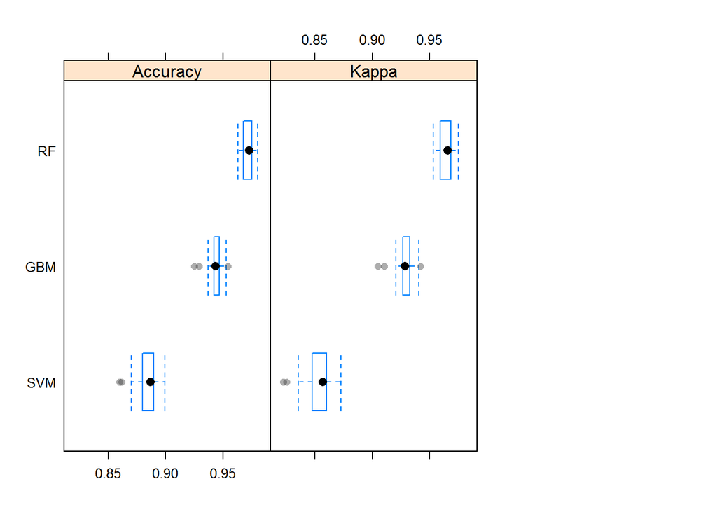

```r
modelCompare <- resamples(list(RF=rfModel, GBM=gbmModel, SVM=svmModel))

theme1 <- trellis.par.get()
theme1$plot.symbol$col = rgb(.2, .2, .2, .4)
theme1$plot.symbol$pch = 16
theme1$plot.line$col = rgb(1, 0, 0, .7)
theme1$plot.line$lwd <- 2
trellis.par.set(theme1)
bwplot(modelCompare, layout = c(3, 1))
```

Probabilities of each **classe** classification of the test data were calculated using the **rf** Random Forest model, both the most likely and second most likely classification were used to solve the submission part of the assignment.

```r
predict(rfModel, newdata=dfTest, type = "prob")
```

```
##        A     B     C     D     E
## 1  0.076 0.642 0.230 0.024 0.028
## 2  0.974 0.016 0.004 0.002 0.004
## 3  0.504 0.388 0.062 0.004 0.042
## 4  0.922 0.004 0.054 0.018 0.002
## 5  0.864 0.038 0.090 0.006 0.002
## 6  0.020 0.146 0.186 0.072 0.576
## 7  0.022 0.016 0.206 0.678 0.078
## 8  0.022 0.722 0.036 0.178 0.042
## 9  1.000 0.000 0.000 0.000 0.000
## 10 0.952 0.034 0.000 0.014 0.000
## 11 0.078 0.682 0.092 0.090 0.058
## 12 0.026 0.098 0.764 0.028 0.084
## 13 0.026 0.880 0.030 0.014 0.050
## 14 1.000 0.000 0.000 0.000 0.000
## 15 0.022 0.060 0.050 0.048 0.820
## 16 0.014 0.020 0.002 0.024 0.940
## 17 0.966 0.000 0.002 0.000 0.032
## 18 0.058 0.810 0.016 0.084 0.032
## 19 0.132 0.834 0.006 0.022 0.006
## 20 0.000 0.998 0.002 0.000 0.000
```